# CEPS Dataset Inspection

2/25/2020

China Education Panel Survey (CEPS, website: https://ceps.ruc.edu.cn/index.php?r=index/index&hl=en) is a nationally representative longitudinal survey designed by National Survey Research Center at Renmin University of China. In 2013, CEPS applied a stratified, multistage sampling design with probability proportional to size (PPS) and randomly selected a school-based, nationally representative sample of 19,487 7th- and 9th-grade students in 438 homerooms of 112 schools in 28 county-level units in mainland China. The full dataset is student-level data from students and their homeroom teachers, subject teachers, school administrators, and parents.

CEPS applied a four-stage random sampling procedure: 1) select 28 county-level units from a total of 2,870 counties with PPS; 2) select 4 schools from all schools serving 7th and/or 9th grades from each sample county with PPS; 3) randomly select 2 homerooms from 7th grade and another 2 from 9th grade in each sample school; and 4) include all students attending school on the survey date in the selected homerooms.

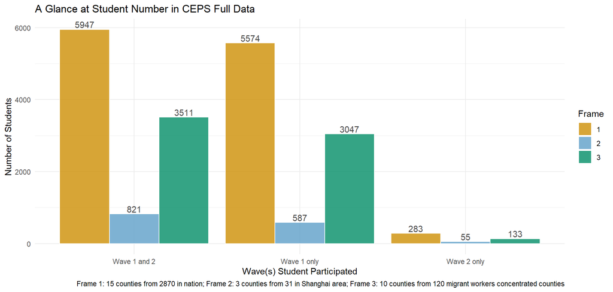

Notice that the 112 schools selected into the full data come from three sampling frames: frame 1 contains 6o schools from 15 counties out of 2870 in the nation, frame 2 contains 3 counties out of 31 in Shanghai area, and frame 3 contains 10 counties from 120 migrant workers concentrated counties. In other words, frame 2 and 3 are supplementary subsamples serving for particular study purpose focusing on student subgroups in Shanghai and from migrant worker families. However, for the generalization purpose of my research, I am more interested in schools from the core sampling frame - frame 1. Please find more details in “My Sample Data” page.